# treemap: mapping to color palettes

Martijn Tennekes

October 14, 2015

This small tutorial is about the mapping of values to color palettes, for treemap types “value” and “manual”.

There are to arguments that determine the mapping to color palettes: `mapping` and `palette`. The arguent `range` does not influence this mapping, as it only defined what range of color values is shown in the legend.

The only difference between “value” and “manual” is the default value for `mapping`. The “value” treemap considers `palette` to be a diverging color palette (say ColorBrewer’s `"RdYlBu"`), and maps it in such a way that 0 corresponds to the middle color (typically white or yellow), `-max(abs(values))` to the left-end color, and `max(abs(values))`, to the right-end color. The “manual” treemap simply maps `min(values)` to the left-end color, `max(values)` to the right-end color, and `mean(range(values))` to the middle color.

```r
library(treemap)
set.seed(20151014)
```

### “value” type treemaps: `mapping=(-max(abs(values)), 0, max(abs(values)))`

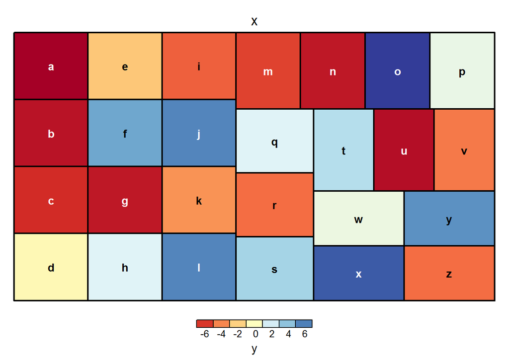

```r
dat1 <- data.frame(letters=letters[1:26], x=1, y=runif(26)*16-8)
treemap(dat1, index="letters", vSize="x", vColor="y", type="value", palette="RdYlBu")
```

You see that the center color (Yl) will automatically be assigned to 0, negative values to Rd-Yl and positive to Yl-Bu:

Example when there are more extreme negative values than positive:

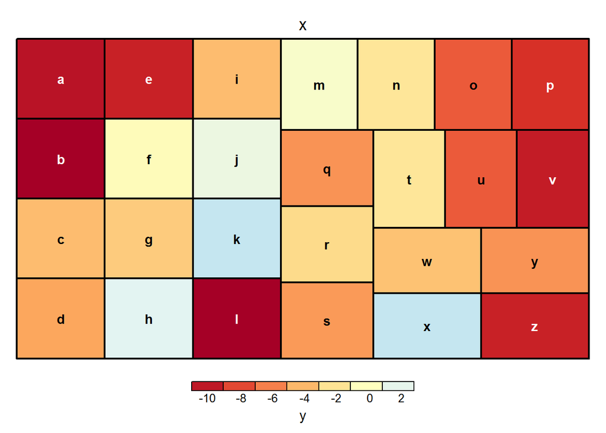

```r
dat2 <- data.frame(letters=letters[1:26], x=1, y=runif(26)*16-12)
treemap(dat2, index="letters", vSize="x", vColor="y", type="value", palette="RdYlBu")
```

The reason why you see only -10 to 2 in the legend (and not -10 to 10), is because the `range` argument is by default c(min(values), max(values)) with a pretty rounding. This can be changed of course:

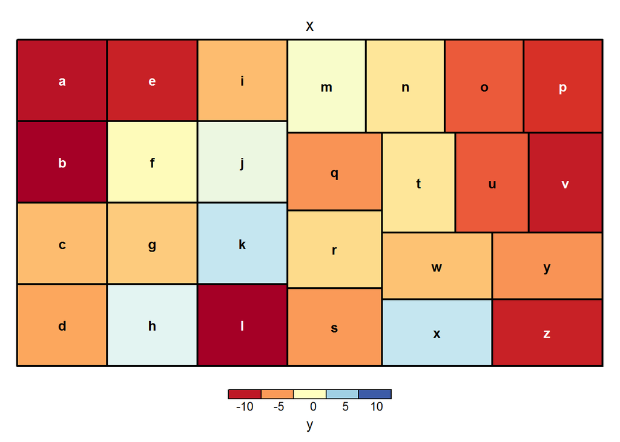

```r
treemap(dat2, index="letters", vSize="x", vColor="y", type="value", palette="RdYlBu", range=c(-10,10))
```

If there are only positive values, only the Yl-Bu half is used:

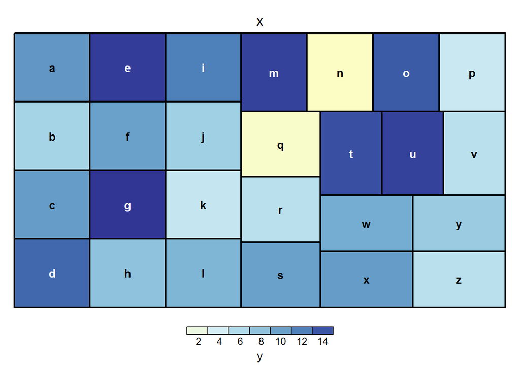

```r
dat3 <- data.frame(letters=letters[1:26], x=1, y=runif(26)*16)
treemap(dat3, index="letters", vSize="x", vColor="y", type="value", palette="RdYlBu")
```

Let’s rerun the examples for `type="manual"`:

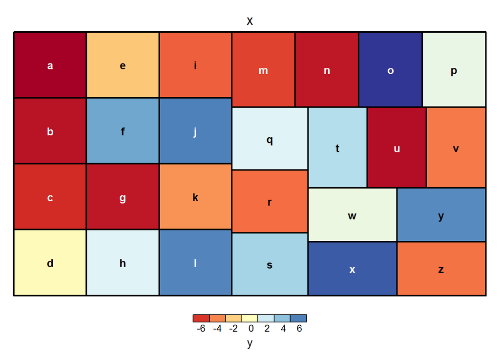

```r
treemap(dat1, index="letters", vSize="x", vColor="y", type="manual", palette="RdYlBu")
```

This is essentially the same treemap as above, because the middle value 0 for “value” is very close to `mean(range(dat1$y))` which is `-0.045`.

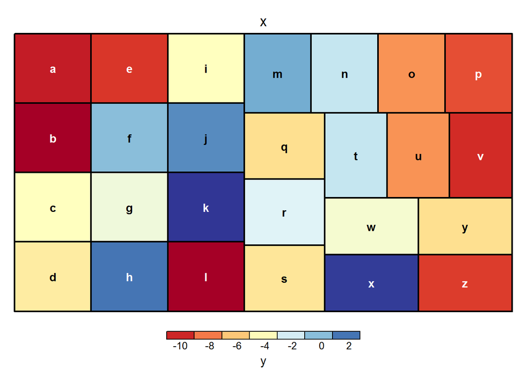

```r
treemap(dat2, index="letters", vSize="x", vColor="y", type="manual", palette="RdYlBu")
```

In this case, yellow will be assigned to the middle value `mean(range(dat2$y))` which is `-3.89`.

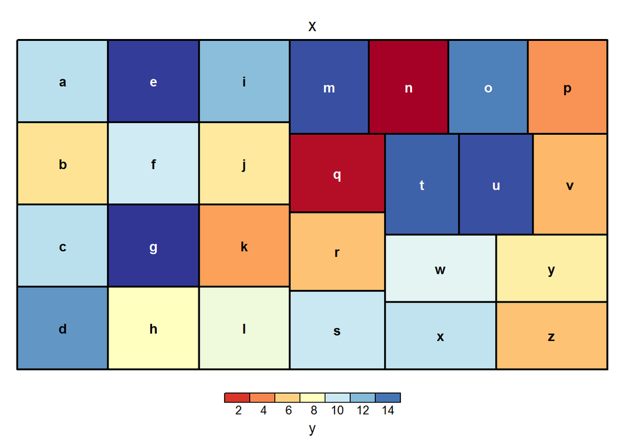

```r
treemap(dat3, index="letters", vSize="x", vColor="y", type="manual", palette="RdYlBu")
```

In contrary to value treemaps, also the lefthand-side range of the diverging palette is used when there are only positive values.

### treemaps with custom mapping

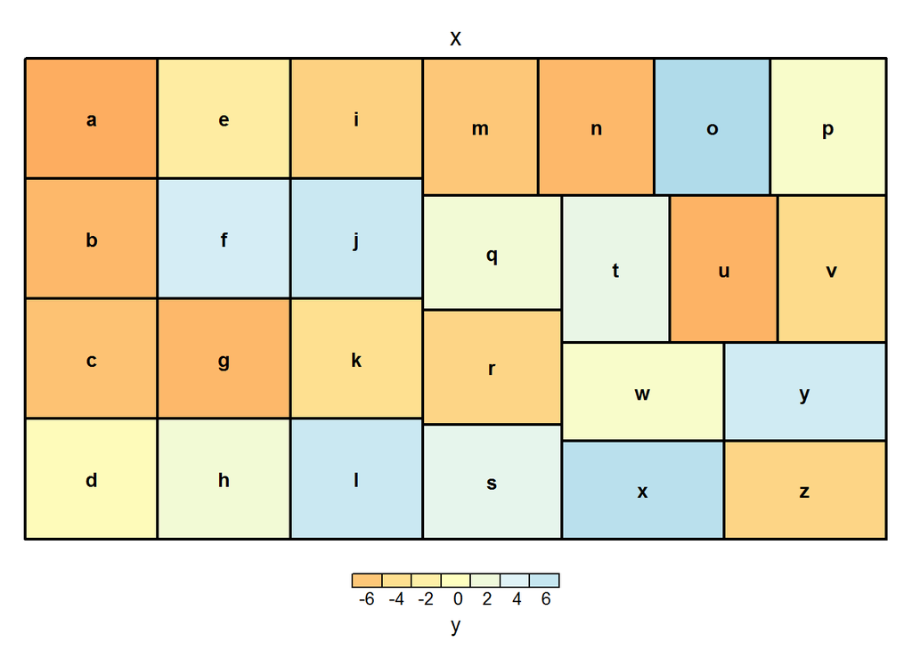

```r
treemap(dat1, index="letters", vSize="x", vColor="y", type="value", palette="RdYlBu", mapping=c(-20, 0, 20))
```

This is an interesting one. Now -20 and 20 are mapped to both ends of the palette. What you get, is that the middle color is still 0 (as with value), but the colors range from orange to light blue, because only middle part of the palette is used.

You don’t see -20 and 20 in the legend, because `range` is by default c(min(values), max(values)) with a pretty rounding. You can change this, of course:

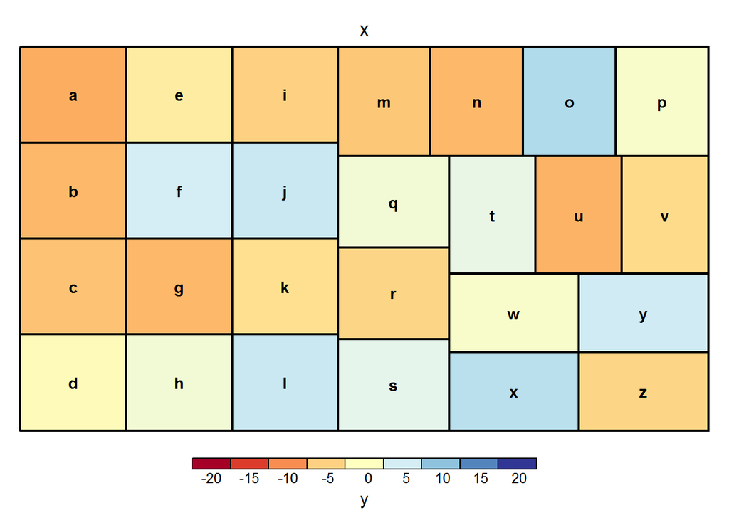

```r
treemap(dat1, index="letters", vSize="x", vColor="y", type="value", palette="RdYlBu", mapping=c(-20, 0, 20), range=c(-20,20))
```

If range falls outside the mapping, the correspinding legend items will be assigned to the end colors of the palette:

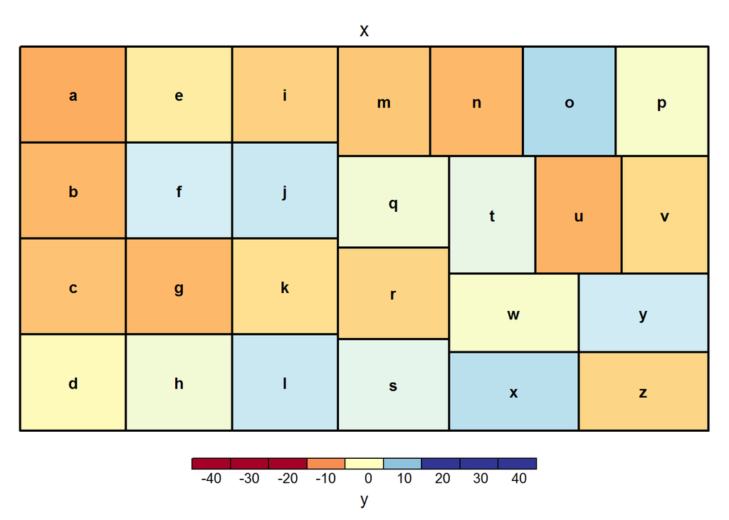

```r
treemap(dat1, index="letters", vSize="x", vColor="y", type="value", palette="RdYlBu", mapping=c(-20, 0, 20), range=c(-40,40))
```

Suppose we want the range of data values to be mapped to the whole palette, with 0 as middle value:

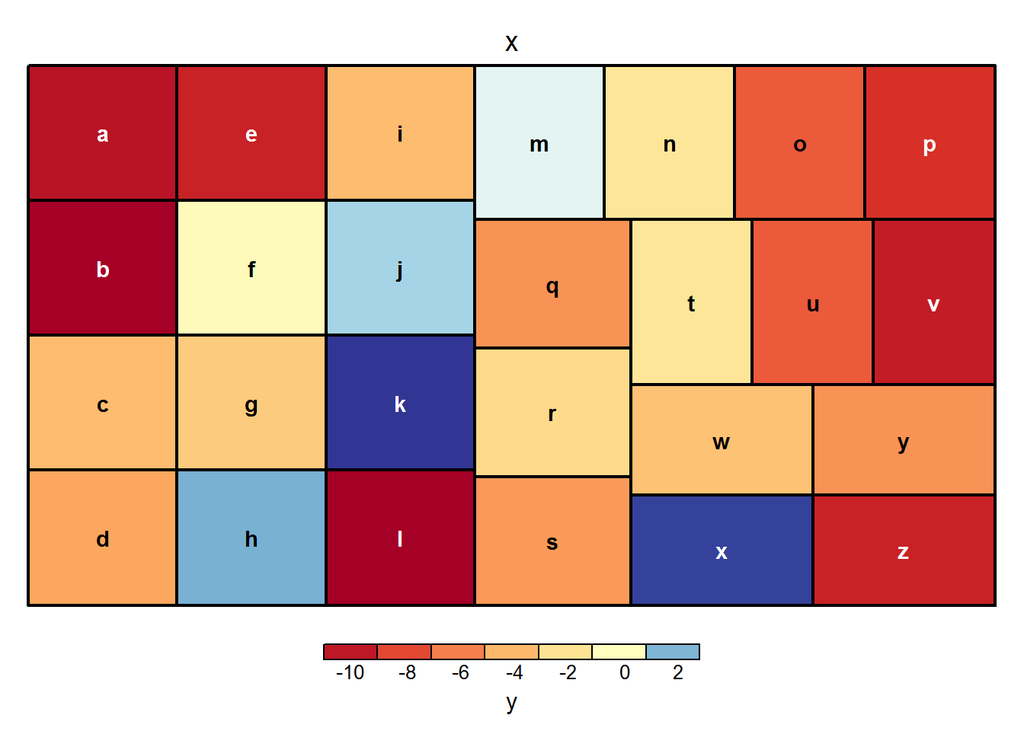

```r
treemap(dat2, index="letters", vSize="x", vColor="y", type="value", palette="RdYlBu", mapping=c(min(dat2$y), 0, max(dat2$y)))
```

Let’s assign 10 to the middle value:

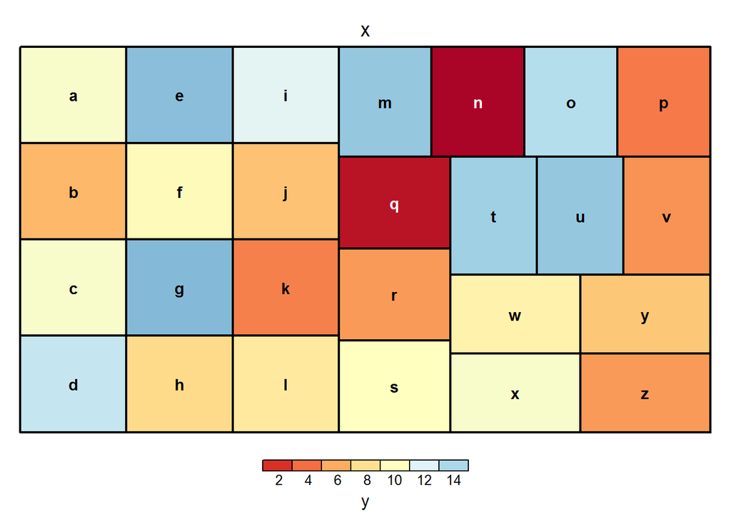

```r
treemap(dat3, index="letters", vSize="x", vColor="y", type="value", palette="RdYlBu", mapping=c(0, 10, 20))
```